# Chapter_12_final_probblems

## 12M4. Fit the following cross-classified multilevel model to the chimpanzees data:

## Li ∼ Binomial(1, pi)

## logit(pi) = αactor[i] + αblock[i] + (βP + βPCCi)Pi

## αactor ∼ Normal(α, σactor)

## αblock ∼ Normal(γ, σblock)

## α,γ,βP,βPC ∼Normal(0,10)

## σactor, σblock ∼ HalfCauchy(0, 1)

```r
library(rethinking)
```

```r
data(chimpanzees)
d <- chimpanzees
d$recipient <- NULL # get rid of NAs
d$block_id <- d$block

m12.4 <- map2stan(
    alist(
     pulled_left ~ dbinom( 1 , p ),
        logit(p) <- a + a_actor[actor] + a_block[block_id] +
                  (bp + bpc*condition)*prosoc_left,
        a_actor[actor] ~ dnorm( 0 , sigma_actor ),
        a_block[block_id] ~ dnorm( 0 , sigma_block ),
        c(a,bp,bpc) ~ dnorm(0,10),
        sigma_actor ~ dcauchy(0,1),
        sigma_block ~ dcauchy(0,1)
),
data=d, warmup=1000 , iter=6000 , chains=4 , cores=3 )
```

[output not shown]

```
##
## WARNING: No variance estimation is
##          performed for num_warmup < 20
##
##
## Chain 1, Iteration: 1 / 1 [100%]  (Sampling)
##  Elapsed Time: 6e-06 seconds (Warm-up)
##                0.000309 seconds (Sampling)
##                0.000315 seconds (Total)
```

```
## Computing WAIC
```

```
## Constructing posterior predictions
```

[output not shown]

```r
m12.m4 <- map2stan(
    alist(
     pulled_left ~ dbinom( 1 , p ),
        logit(p) <- a + a_actor[actor] + a_block[block_id] +
                    (bp + bpc*condition)*prosoc_left,
        a_actor[actor] ~ dnorm( a , sigma_actor ),
        a_block[block_id] ~ dnorm( y , sigma_block ),
        c(a,y,bp,bpc) ~ dnorm(0,10),
        c(sigma_actor,sigma_block) ~ dcauchy(0,1)
),
data=d, warmup=1000 , iter=6000 , chains=4 , cores=3 )
```

[output not shown]

```
##
## WARNING: No variance estimation is
##          performed for num_warmup < 20
##
##
## Chain 1, Iteration: 1 / 1 [100%]  (Sampling)
##  Elapsed Time: 4e-06 seconds (Warm-up)
##                0.000441 seconds (Sampling)
##                0.000445 seconds (Total)
```

```
## Computing WAIC
## Constructing posterior predictions
```

[output not shown]

now the alpha is not being added and block_ids should also be off….

Each of the parameters in those comma-separated lists gets the same independent prior. Compare the posterior distribution to that produced by the similar cross-classified model from the chapter. Also compare the number of effective samples. Can you explain the differences?

The weights are very similar for both of the models

```r
### compare the posterior distributions!!!

compare(m12.4,m12.m4)
```

```
##         WAIC pWAIC dWAIC weight    SE dSE
## m12.m4 532.4  10.7   0.0   0.51 19.69  NA
## m12.4  532.5  10.3   0.1   0.49 19.68 0.5
```

```r
coeftab(m12.4,m12.m4)
```

```
##             m12.4   m12.m4
## a_actor[1]    -1.15   -0.90
## a_actor[2]     4.20    4.53
## a_actor[3]    -1.46   -1.20
## a_actor[4]    -1.46   -1.20
## a_actor[5]    -1.15   -0.89
## a_actor[6]    -0.20    0.05
## a_actor[7]     1.34    1.59
## a_block[1]    -0.18   -0.34
## a_block[2]     0.04   -0.05
## a_block[3]     0.05   -0.03
## a_block[4]     0.01   -0.10
## a_block[5]    -0.03   -0.15
## a_block[6]     0.12    0.04
## a              0.43    0.28
## bp             0.83    0.82
## bpc           -0.14   -0.13
## sigma_actor    2.27    2.24
## sigma_block    0.23    0.28
## y                NA    -0.1
## nobs            504     504
```

```r
precis(m12.4,depth=2)
```

```
##              Mean StdDev lower 0.89 upper 0.89 n_eff Rhat
## a_actor[1]  -1.15   0.94      -2.54       0.32  3619    1
## a_actor[2]   4.20   1.63       1.86       6.49  5459    1
## a_actor[3]  -1.46   0.95      -2.94      -0.05  3548    1
## a_actor[4]  -1.46   0.95      -2.94      -0.05  3659    1
## a_actor[5]  -1.15   0.94      -2.57       0.30  3623    1
## a_actor[6]  -0.20   0.94      -1.65       1.24  3607    1
## a_actor[7]   1.34   0.97      -0.13       2.85  3814    1
## a_block[1]  -0.18   0.23      -0.53       0.12  4110    1
## a_block[2]   0.04   0.19      -0.23       0.34  9501    1
## a_block[3]   0.05   0.19      -0.22       0.37  9641    1
## a_block[4]   0.01   0.19      -0.29       0.29 11046    1
## a_block[5]  -0.03   0.19      -0.33       0.25  9577    1
## a_block[6]   0.12   0.21      -0.17       0.44  6444    1
## a            0.43   0.93      -0.92       1.91  3496    1
## bp           0.83   0.26       0.43       1.25 12148    1
## bpc         -0.14   0.29      -0.63       0.31 11293    1
## sigma_actor  2.27   0.92       1.03       3.38  5364    1
## sigma_block  0.23   0.18       0.01       0.43  2391    1
```

```r
precis(m12.m4,depth=2)
```

```
##              Mean StdDev lower 0.89 upper 0.89 n_eff Rhat
## a_actor[1]  -0.90   4.42      -8.03       5.89   583 1.01
## a_actor[2]   4.53   4.72      -3.10      11.49   287 1.02
## a_actor[3]  -1.20   4.41      -8.33       5.57   570 1.01
## a_actor[4]  -1.20   4.42      -8.64       5.29   573 1.01
## a_actor[5]  -0.89   4.42      -8.24       5.62   556 1.01
## a_actor[6]   0.05   4.42      -7.27       6.65   567 1.01
## a_actor[7]   1.59   4.42      -5.78       8.14   564 1.01
## a_block[1]  -0.34   8.78     -13.37      13.99   549 1.01
## a_block[2]  -0.05   8.78     -13.19      14.21   537 1.01
## a_block[3]  -0.03   8.78     -13.18      14.17   537 1.01
## a_block[4]  -0.10   8.78     -13.27      14.13   539 1.01
## a_block[5]  -0.15   8.78     -12.97      14.40   540 1.01
## a_block[6]   0.04   8.78     -12.86      14.45   532 1.01
## a            0.28   4.42      -7.20       6.54   513 1.01
## y           -0.10   8.78     -13.17      14.17   538 1.01
## bp           0.82   0.26       0.43       1.25   514 1.01
## bpc         -0.13   0.29      -0.61       0.33  1777 1.00
## sigma_actor  2.24   0.97       0.85       3.28   576 1.01
## sigma_block  0.28   0.17       0.09       0.48   371 1.02
```

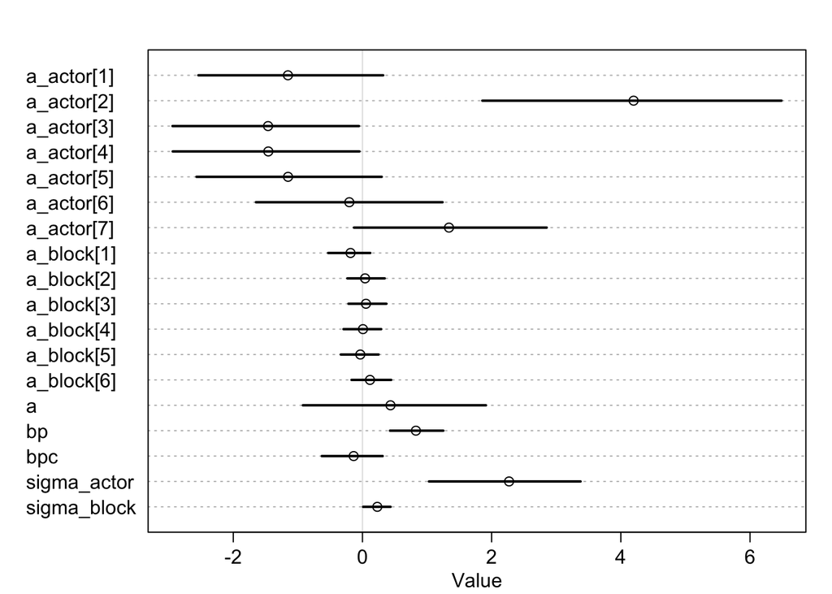

```r
plot(precis(m12.4,depth=2)) # also plot
```

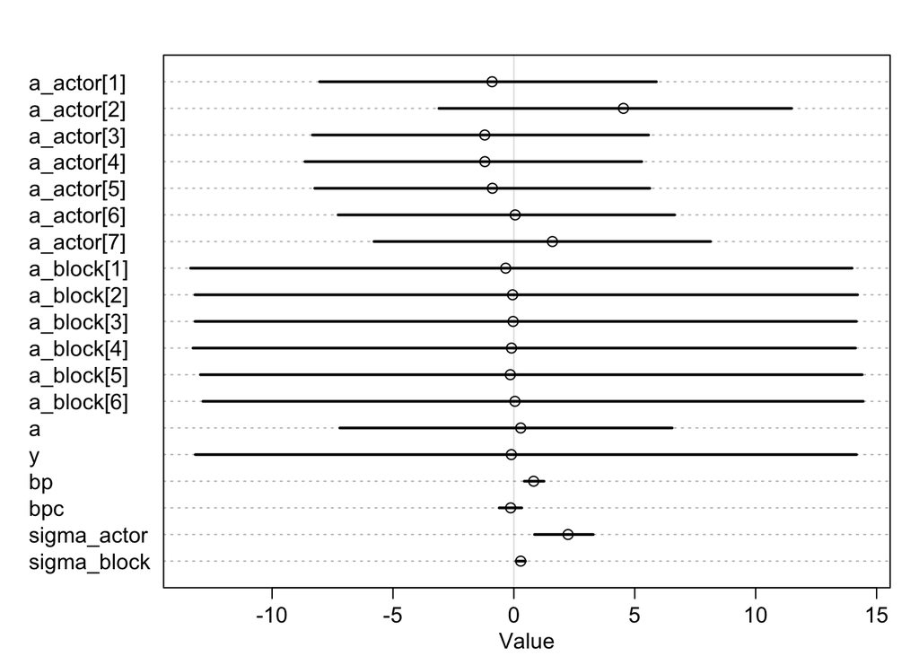

```r
par(mfrow=c(1,1))
plot(precis(m12.m4,depth=2)) # also plot
```

```r
par(mfrow=c(1,1))
```

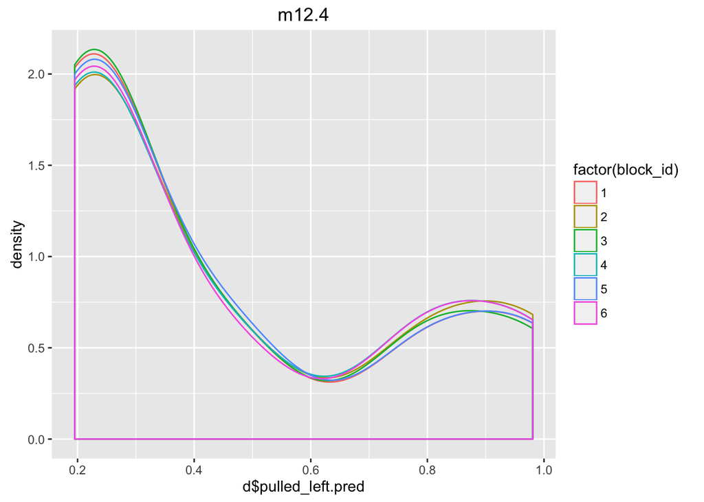

```r
post <- extract.samples(m12.4)
d$pulled_left.pred <- logistic( apply( post$a_actor , 2 , median ) )
ggplot(d, aes(d$pulled_left.pred)) + geom_density(aes(colour=factor(block_id))) + labs(title = "m12.4")
```

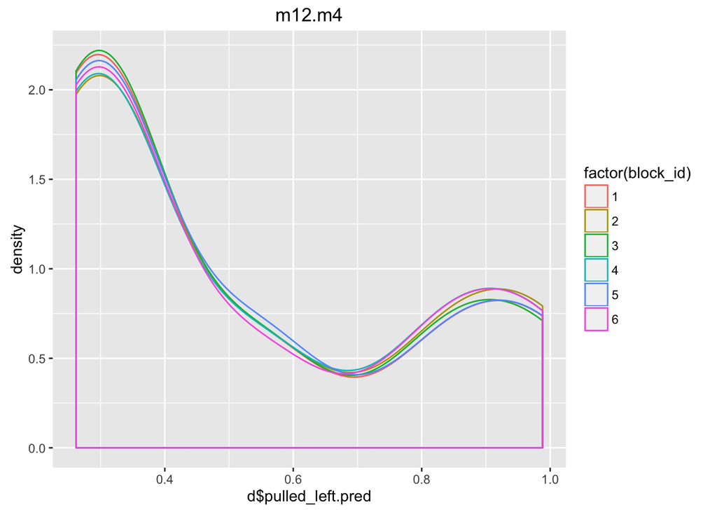

```r
post <- extract.samples(m12.m4)
d$pulled_left.pred <- logistic( apply( post$a_actor , 2 , median ) )
ggplot(d, aes(d$pulled_left.pred)) + geom_density(aes(colour=factor(block_id))) + labs(title = "m12.m4")
```

## 12H2. Return to the Trolley data, data(Trolley), from Chapter 11. Define and fit a varying intercepts model for these data. Cluster intercepts on individual participants, as indicated by the unique values in the id variable. Include action, intention, and contact as ordinary terms. Compare the varying intercepts model and a model that ignores individuals, using both WAIC and posterior predictions. What is the impact of individual variation in these data?

```r
##data(Trolley)
##d <- Trolley
##summary(d)
##str(d)
##a_id
###all zero or 1
###action
###interion
###contact
##d$recipient <- NULL

### change to map2stan format



##m11.1stan <- map2stan(
##    alist(
##        response ~ dordlogit( phi , cutpoints ),
##        phi <-  bA*action + bI*intention + bC*contact,
##        cutpoints ~ dnorm(0,10),
##        c(bA,bI,bC) ~ dnorm(0,10)
##),
##data=d, start=list(cutpoints=c(-2,-1,0,1,2,2.5)) , chains=2 , cores=2 )

## need depth=2 to show vector of parameters
##precis(m11.1stan,depth=2)



##m11.3 <- map2stan(
##    alist(
##        response ~ dordlogit( phi , c(a1,a2,a3,a4,a5,a6) ) ,
##        phi <- bA*action + bI*intention + bC*contact +
##            bAI*action*intention + bCI*contact*intention ,
##        c(bA,bI,bC,bAI,bCI) ~ dnorm(0,10),
##        c(a1,a2,a3,a4,a5,a6) ~ dnorm(0,10)
##),
##data=d , start=list(a1=-1.9,a2=-1.2,a3=-0.7,a4=0.2,a5=0.9,a6=1.8), warmup=1000 , iter=6000 , chains=4 , cores=3  )


##m11.3 <- map(
##    alist(
##        response ~ dordlogit( phi , c(a1,a2,a3,a4,a5,a6) ) ,
##        phi <- a + a_id[id] + bA*action + bI*intention + bC*contact +
##            bAI*action*intention + bCI*contact*intention ,
##        a_id[id??] ~ dnorm( 0 , sigma_id ),
##        sigma_id ~ dcauchy(0,1),
##        c(bA,bI,bC,bAI,bCI) ~ dnorm(0,10),
##        c(a,a1,a2,a3,a4,a5,a6) ~ dnorm(0,10)
##),
##data=d , start=list(a1=-1.9,a2=-1.2,a3=-0.7,a4=0.2,a5=0.9,a6=1.8) )

##a_actor[actor] ~ dnorm( 0 , sigma_actor ),
##        a_block[block_id] ~ dnorm( 0 , sigma_block ),
##        c(a,bp,bpc) ~ dnorm(0,10),
##        sigma_actor ~ dcauchy(0,1),
##        sigma_block ~ dcauchy(0,1)


##compare()
```

## 12H3. The Trolley data are also clustered by story, which indicates a unique narrative for each vignette. Define and fit a cross-classiffied varying intercepts model with both id and story. Use the same ordinary terms as in the previous problem. Compare this model to the previous models. What do you infer about the impact of different stories on responses?

add a cluster for story